# Simple linear regression practical

```python
import pandas as pd
import matplotlib.pyplot as plt
import numpy as np
%matplotlib inline #using this we can display all visualization graph within this jupyter'''
```

```
UsageError: unrecognized arguments: #using this we can display all visualization graph within this jupyter'''
```

```python
df = pd.read_csv('Salary_dataset.csv')
```

```python
df.head()
```

|  | YearsExperience | Salary |
| --- | --- | --- |
| 0 | 1.2 | 39344 |
| 1 | 1.4 | 46206 |
| 2 | 1.6 | 37732 |
| 3 | 2.1 | 43526 |
| 4 | 2.3 | 39892 |

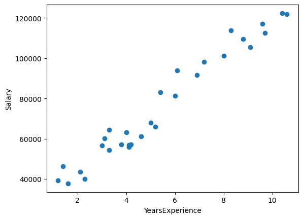

```python
### Scatter plot : using this we can plot data on x and y axis (we gonna see how the data related on the basis on x and y axis)
plt.scatter(df['YearsExperience'], df['Salary'])
#lets label x nd y axis
plt.xlabel('YearsExperience')
plt.ylabel('Salary')
```

```python
# we use correlation when we want to find the whether this relationship is positive or negative
df.corr()
```

|  | YearsExperience | Salary |
| --- | --- | --- |
| YearsExperience | 1.000000 | 0.978242 |
| Salary | 0.978242 | 1.000000 |

This is hightly corerelated because YearsExperience is 1.000000 too much near by Salary 0.978242

```
'<----- this pairplot basically do is in dramatically way , it will try to show you that it will try to display specific coordinates'
```

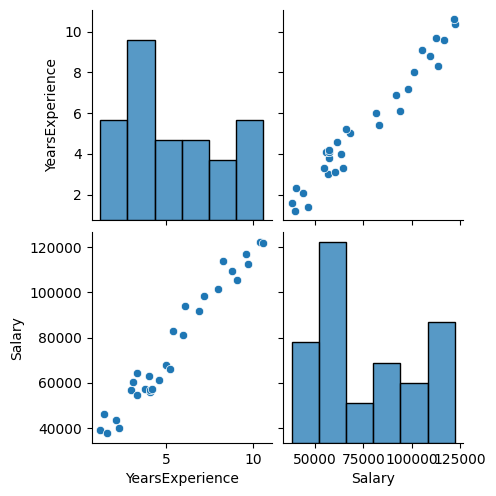

```python
# seaborn for visualization
import seaborn as sns
sns.pairplot(df)
'''<----- this pairplot basically do is in dramatically way , it will try to show you that it will try to display specific coordinates'''
```

```python
# creating independenat and depedant features
X = df['YearsExperience']
X
```

[output not shown]

```python
type(X) #its a series not a dataframe
```

[output not shown]

```python
X
```

[output not shown]

```python
type(df) #its a dataframe
```

[output not shown]

```python
df
```

|  | YearsExperience | Salary |
| --- | --- | --- |
| 0 | 1.2 | 39344 |
| 1 | 1.4 | 46206 |
| 2 | 1.6 | 37732 |
| 3 | 2.1 | 43526 |
| 4 | 2.3 | 39892 |
| 5 | 3.0 | 56643 |
| 6 | 3.1 | 60151 |
| 7 | 3.3 | 54446 |
| 8 | 3.3 | 64446 |
| 9 | 3.8 | 57190 |
| 10 | 4.0 | 63219 |
| 11 | 4.1 | 55795 |
| 12 | 4.1 | 56958 |
| 13 | 4.2 | 57082 |
| 14 | 4.6 | 61112 |
| 15 | 5.0 | 67939 |
| 16 | 5.2 | 66030 |
| 17 | 5.4 | 83089 |
| 18 | 6.0 | 81364 |
| 19 | 6.1 | 93941 |
| 20 | 6.9 | 91739 |
| 21 | 7.2 | 98274 |
| 22 | 8.0 | 101303 |
| 23 | 8.3 | 113813 |
| 24 | 8.8 | 109432 |
| 25 | 9.1 | 105583 |
| 26 | 9.6 | 116970 |
| 27 | 9.7 | 112636 |
| 28 | 10.4 | 122392 |
| 29 | 10.6 | 121873 |

Series basically means just a single record

### NOTE: our independdent feature always should be in a 2D or data frame

```python
df[['YearsExperience']] #this 2d array converts data(series) into dataframe
```

|  | YearsExperience |
| --- | --- |
| 0 | 1.2 |
| 1 | 1.4 |
| 2 | 1.6 |
| 3 | 2.1 |
| 4 | 2.3 |
| 5 | 3.0 |
| 6 | 3.1 |
| 7 | 3.3 |
| 8 | 3.3 |
| 9 | 3.8 |
| 10 | 4.0 |
| 11 | 4.1 |
| 12 | 4.1 |
| 13 | 4.2 |
| 14 | 4.6 |
| 15 | 5.0 |
| 16 | 5.2 |
| 17 | 5.4 |
| 18 | 6.0 |
| 19 | 6.1 |
| 20 | 6.9 |
| 21 | 7.2 |
| 22 | 8.0 |
| 23 | 8.3 |
| 24 | 8.8 |
| 25 | 9.1 |
| 26 | 9.6 |
| 27 | 9.7 |
| 28 | 10.4 |
| 29 | 10.6 |

```python
X=df[['YearsExperience']]
np.array(X)
```

```
array([[ 1.2],
       [ 1.4],
       [ 1.6],
       [ 2.1],
       [ 2.3],
       [ 3. ],
       [ 3.1],
       [ 3.3],
       [ 3.3],
       [ 3.8],
       [ 4. ],
       [ 4.1],
       [ 4.1],
       [ 4.2],
       [ 4.6],
       [ 5. ],
       [ 5.2],
       [ 5.4],
       [ 6. ],
       [ 6.1],
       [ 6.9],
       [ 7.2],
       [ 8. ],
       [ 8.3],
       [ 8.8],
       [ 9.1],
       [ 9.6],
       [ 9.7],
       [10.4],
       [10.6]])
```

```python
X.ndim
```

```
2
```

```python
X.shape
```

```
(30, 1)
```

```python
X = df[['YearsExperience']]
y = df['Salary'] #this independent variable can be series or 1d array
```

```python
y
```

```
0      39344
1      46206
2      37732
3      43526
4      39892
5      56643
6      60151
7      54446
8      64446
9      57190
10     63219
11     55795
12     56958
13     57082
14     61112
```

[output cut: 16 more lines]

```python
np.array(y).shape
```

```
(30,)
```

```python
##Standardization
```

```python
#Train Test SPlit
from sklearn.model_selection import train_test_split
```

```python
X_train, X_test, y_train, y_test = train_test_split(X,y, test_size = 0.25, random_state = 42)
```

```python
#standardization
from sklearn.preprocessing import StandardScaler
```

```python
scaler=StandardScaler()
X_train=scaler.fit_transform(X_train)
```

Very imp interview question:

We do not use .fit_transform for X_test because whenever we say transform in X_test data we use mean and standard deviation from X_train of data and apply the same formula is Z Score = x-mean/standard deviation because if we do the mean and standard deviation of X_test it will leak data to X_train so it wil be a problem because it will understand X_test data asldo and we don't want that so we do this and this we will also do in PCA

```python
X_test=scaler.transform(X_test)
```

```python
## Apply Simple Linear regression
from sklearn.linear_model import LinearRegression
```

```python
regression = LinearRegression(n_jobs=-1) #intialize the object
```

```python
regression.fit(X_train, y_train)
```

```
LinearRegression(n_jobs=-1)
```

```python
print("Coefficient or slop:",regression.coef_) #this is a slop and we got single value because
print("Intercept:",regression.intercept_)
```

```
Coefficient or slop: [25063.1519945]
Intercept: 70417.40909090907
```

we got single value as coefficient because this comes in y hat = beta0(intercept , we can get using regression.intercept_)+ beta1(coefficient which we calculated in upper cell). x1(x1 are data points and nothing but weights)

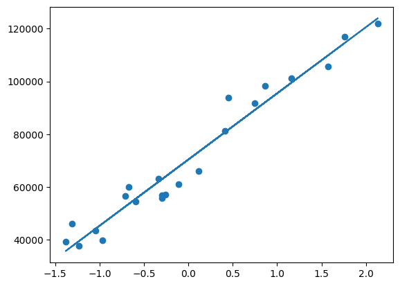

```python
## w.e.t training data we plot best fit line
plt.scatter(X_train, y_train)
plt.plot(X_train, regression.predict(X_train))
```

### Prediction of test data

1. Predicted salary output = intercept_ + coef_
2. y_pred_test = 70417 + 25063(X_test)

```python
##Prediction for test data
y_pred = regression.predict(X_test)
```

```python
#Performance metrics
from sklearn.metrics import mean_absolute_error, mean_squared_error
```

```python
mse = mean_squared_error(y_test, y_pred)
mae = mean_absolute_error(y_test, y_pred)
rmse=np.sqrt(mse)
print(mse)
print(mae)
print(rmse)
```

```
38802588.992470615
5056.995466663588
6229.172416338354
```

here getting big errors because we are comparing x scaled values with original data in ytest and y_pred so we will scaled y_test and y_pred also

```python
# Scale X
scaler_X = StandardScaler()
X_train = scaler_X.fit_transform(X_train)
X_test = scaler_X.transform(X_test)

# Scale y
scaler_y = StandardScaler()
y_train_scaled = scaler_y.fit_transform(y_train.values.reshape(-1, 1))
y_test_scaled  = scaler_y.transform(y_test.values.reshape(-1, 1))   # FIXED

# Train model on SCALED y
regression = LinearRegression()
regression.fit(X_train, y_train_scaled)

# Predict SCALED y
y_pred_scaled = regression.predict(X_test)

# Compare scaled values
mse = mean_squared_error(y_test_scaled, y_pred_scaled)
mae = mean_absolute_error(y_test_scaled, y_pred_scaled)
rmse = np.sqrt(mse)

print(mse)
print(mae)
print(rmse)
```

```
0.059015912181313995
0.1972181018644611
0.24293190852852986
```

## R square

formula **R^2 = 1 - SSR/SST** R^2= coefficient of determination SSR = sum of square of residual SST = Total sum of squares

```python
from sklearn.metrics import r2_score
```

```python
score = r2_score(y_test, y_pred)
print(score)
```

```
0.9347210011126783
```

**Adjusted R2 = 1 - [(1-R2)*(n-1)/(n-k-1)]** where, R2 = The R2 of the model n = The number of the observations k = The number of the predicted variables

```python
#display adjusted R-squared
1 - (1 - score) * len((y_test)-1)/len((y_test)-X_test.shape[1]-1)
```

```
0.9347210011126783
```

```python
# OLS linear regression
import statsmodels.api as sm
```

```python
model = sm.OLS(y_train, X_train).fit()
```

```python
prediction = model.predict(X_test)
print(prediction)
```

```
[ 45023.47271018    979.6971356   31904.0501986    4728.10356748
 -14951.03019988 -10265.52216003  51583.18396597  36589.55823845]
```

```python
print(model.summary())
```

```
                                 OLS Regression Results
=======================================================================================
Dep. Variable:                 Salary   R-squared (uncentered):                   0.112
Model:                            OLS   Adj. R-squared (uncentered):              0.070
Method:                 Least Squares   F-statistic:                              2.645
Date:                Sun, 07 Dec 2025   Prob (F-statistic):                       0.119
Time:                        20:54:55   Log-Likelihood:                         -276.85
No. Observations:                  22   AIC:                                      555.7
Df Residuals:                      21   BIC:                                      556.8
Df Model:                           1
Covariance Type:            nonrobust
==============================================================================
                 coef    std err          t      P>|t|      [0.025      0.975]
------------------------------------------------------------------------------
x1          2.506e+04   1.54e+04      1.626      0.119   -6987.275    5.71e+04
==============================================================================
Omnibus:                        0.869   Durbin-Watson:                   0.011
Prob(Omnibus):                  0.648   Jarque-Bera (JB):                0.870
Skew:                           0.355   Prob(JB):                        0.647
Kurtosis:                       2.332   Cond. No.                         1.00
==============================================================================

Notes:
[1] R² is computed without centering (uncentered) since the model does not contain a constant.
[2] Standard Errors assume that the covariance matrix of the errors is correctly specified.
```

```python
## Prediction for new data
regression.predict(scaler.transform([[72]])) #72 is the experience and 24.52 is salary but it is scaled so we use inverse_tranform for getting real salary
```

```
array([[24.52408611]])
```

```python
scaler_y.inverse_transform([[24.52408611]])
```

```
array([[699255.18366583]])
```